# Praca domowa 2

Gabriel Grabowski

## Dane

Dane wykorzystane w Pracy domowej 2 opisują wycenę nieruchmości. Każda obserwacja jest pewną nieruchmością, która posiada informacje takie jak powierzchnia, liczba pokoi, liczba łazienek i wiele więcj. Opis wszystkich kolumn w pliku `README.md`.

## Zadanie 1

Jak wygląda rozkład ceny nieruchomości w poszczególnych kodach pocztowych na przestrzeni lat? Rozważamy kody pocztowe, które mają więcej niż 280 posiadłości.

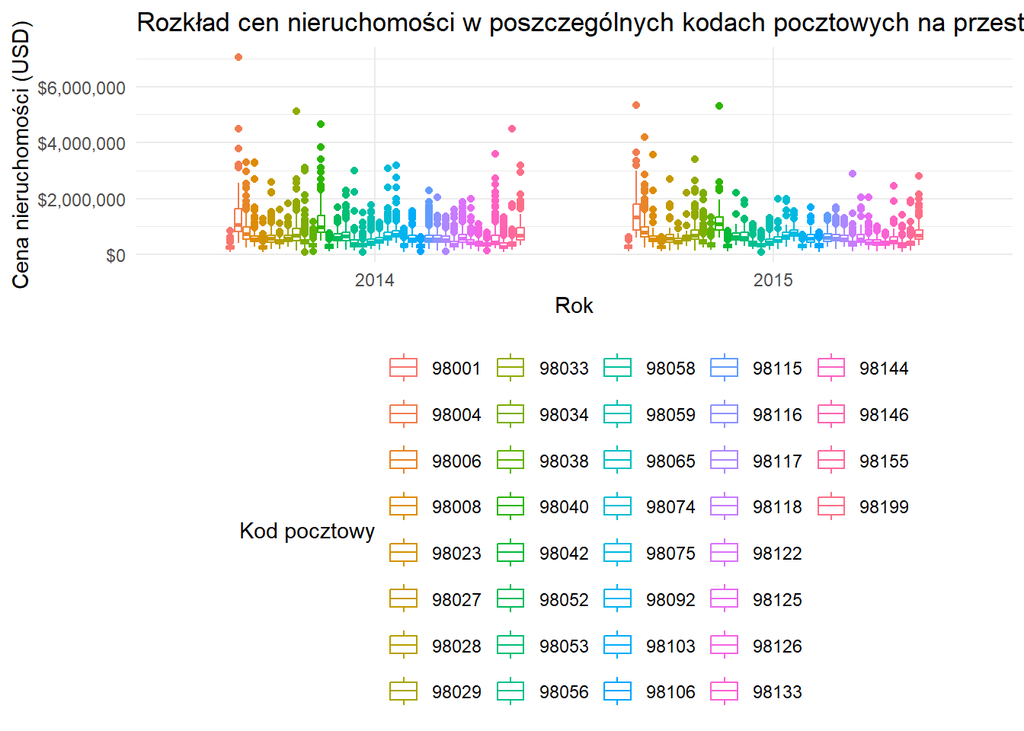

```r
df_1 <- house_data %>%
  mutate(year = substr(date, 1, 4)) %>%
  group_by(zipcode) %>%
  filter(n() > 280) %>%
  ungroup()

ggplot(df_1, aes(x = year, y = price, color = factor(zipcode))) +
  geom_boxplot() +
  labs(
    title = "Rozkład cen nieruchomości w poszczególnych kodach pocztowych na przestrzeni lat",
    x = "Rok",
    y = "Cena nieruchomości (USD)",
    color = "Kod pocztowy"
  ) +
  theme_minimal() +
  theme(legend.position = "bottom") +
  scale_y_continuous(labels = scales::dollar_format())
```

**Komentarz: Ceny z lat 2014 i 2015 są bardzo podobne, aczkolwiek w 2015 roku ceny są o wiele mniej skrajne**

## Zadanie 2

Czy jest różnica w rozkładzie ceny nierchomości od powierzchni mieszkalnej uwzględniając podział na nieruchomości z piwnicą i bez?

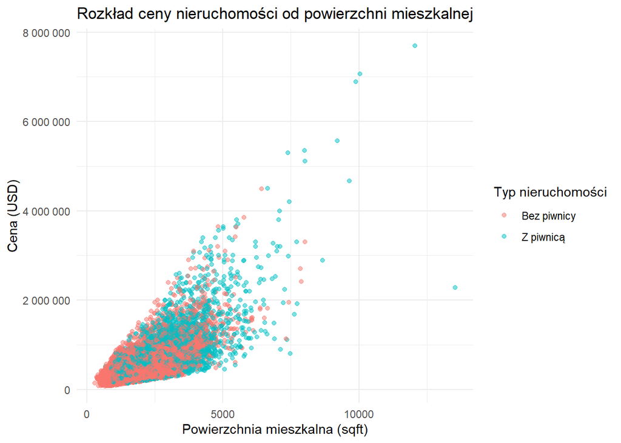

```r
df_2 <- house_data %>%
  mutate(basement = ifelse(sqft_basement > 0, "Z piwnicą", "Bez piwnicy"))

ggplot(df_2, aes(x = sqft_living, y = price, color = basement)) +
  geom_point(alpha = 0.5) +
  scale_y_continuous(labels = scales::label_number()) +
  labs(title = "Rozkład ceny nieruchomości od powierzchni mieszkalnej",
       x = "Powierzchnia mieszkalna (sqft)",
       y = "Cena (USD)",
       color = "Typ nieruchomości") +
  theme_minimal()
```

## Zadanie 3

Jaka jest zależność pomiędzy jakością wykończenia nieruchomości a liczbą pięter?

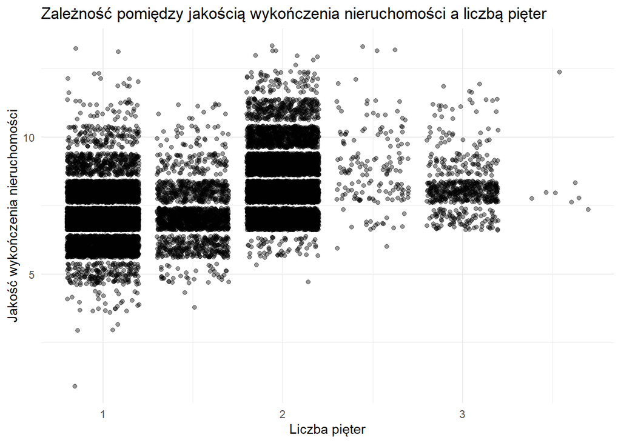

```r
ggplot(house_data, aes(x = floors, y = grade)) +
  geom_jitter(alpha = 0.4) +
  labs(title = "Zależność pomiędzy jakością wykończenia nieruchomości a liczbą pięter",
       x = "Liczba pięter",
       y = "Jakość wykończenia nieruchomości") +
  theme_minimal()
```

## Zadanie 4

Jaka jest zależność między powierzchnią mieszkalną nieruchomości a powierzchnią gruntu w podziale na liczbę sypialni?

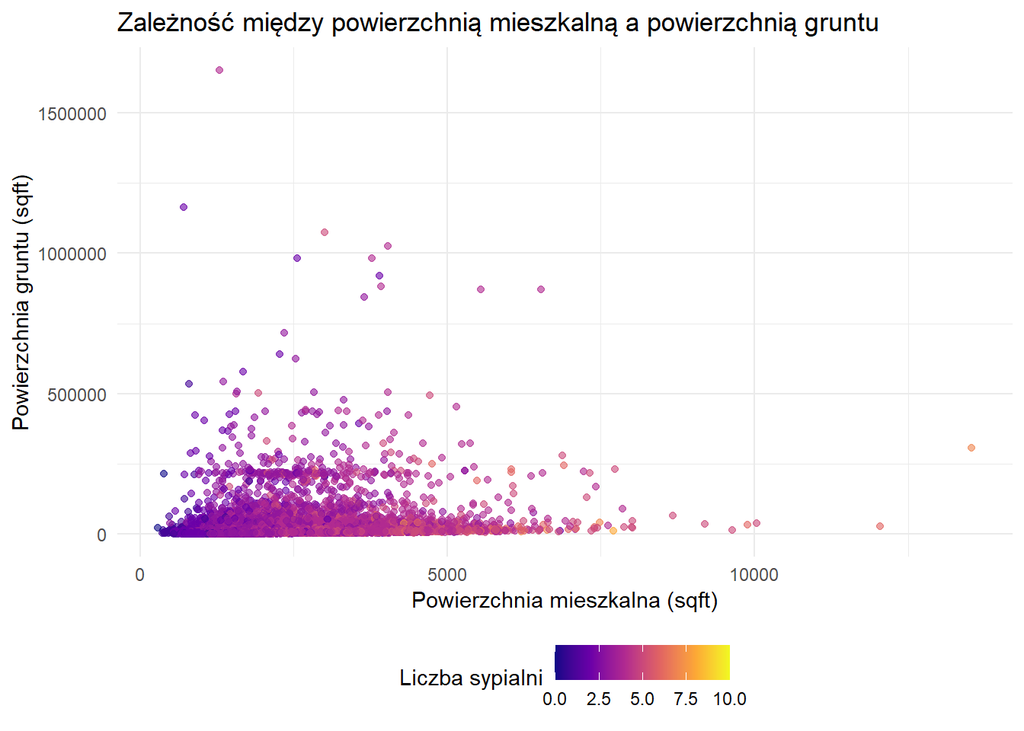

```r
ggplot(house_data, aes(x = sqft_living, y = sqft_lot)) +
  geom_point(aes(color = bedrooms), alpha = 0.6) +
  scale_color_viridis_c(option = "plasma", name = "Liczba sypialni", limits = c(0, 10)) +
  labs(
    title = "Zależność między powierzchnią mieszkalną a powierzchnią gruntu",
    x = "Powierzchnia mieszkalna (sqft)",
    y = "Powierzchnia gruntu (sqft)"
  ) +
  theme_minimal() +
  theme(legend.position = "bottom")
```

**Komentarz: Nie widać większej zależności, aczkolwiek przy skrajnych, dużych wartościach powierzchni mieszkaniowej, mamy do czynienia ze stosunkowo małą powierzchnią gruntu.**

## Zadanie 5

Rozważmy tylko nieruchomości, które miały remont. W której dekadzie było najwięcej przeprowadzonych remontów? Czy w poszczególnych dekadach jest porównywalny procent nieruchmości dla każdej wartości miary jakości i wykończenia nieruchomości?

```r
df_5 <- house_data %>%
  filter(yr_renovated != 0) %>%
  mutate(renovation_decade = floor(yr_renovated / 10) * 10) %>%
  count(renovation_decade) %>%
  arrange(desc(n))
print(df_5)
```

```
##   renovation_decade   n
## 1              2000 272
## 2              2010 186
## 3              1990 182
## 4              1980 152
## 5              1970  56
## 6              1960  34
## 7              1950  22
## 8              1940   9
## 9              1930   1
```

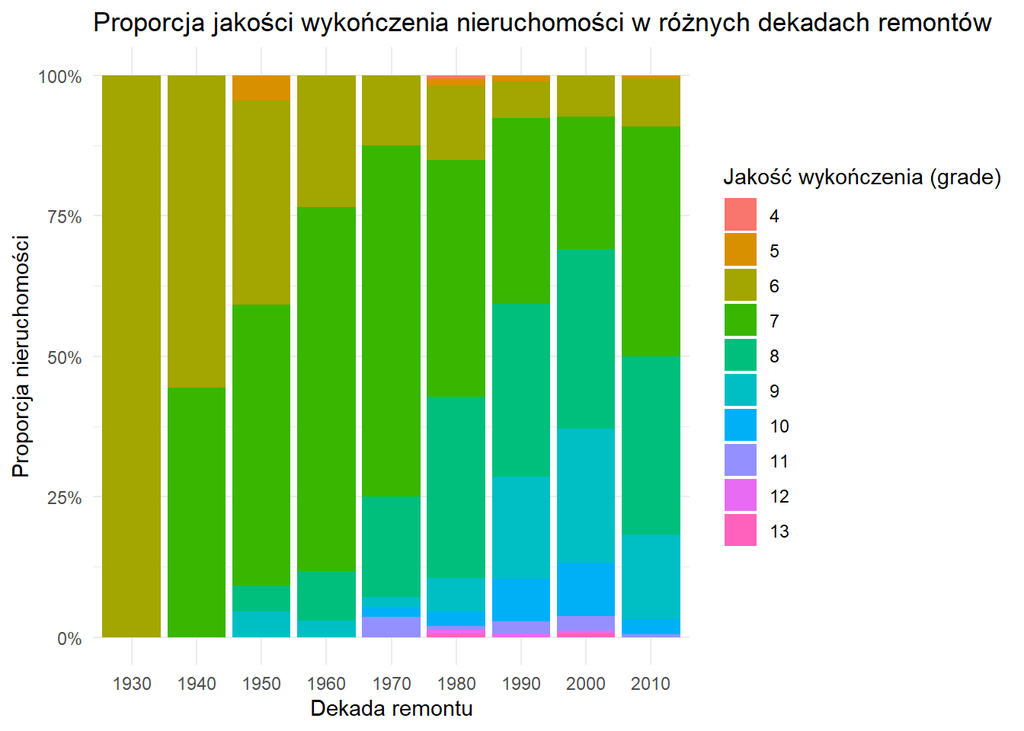

```r
ggplot(house_data %>% mutate(renovation_decade = floor(yr_renovated / 10) * 10) %>% filter(renovation_decade != 0), aes(x = factor(renovation_decade), fill = factor(grade))) +
  geom_bar(position = "fill") +
  labs(
    title = "Proporcja jakości wykończenia nieruchomości w różnych dekadach remontów",
    x = "Dekada remontu",
    y = "Proporcja nieruchomości",
    fill = "Jakość wykończenia (grade)"
  ) +
  scale_y_continuous(labels = scales::percent) +
  theme_minimal()
```

**Komentarz: Najwięcej remontów było w dekadzie 2000-2010, i również w tej dekadzie ocena jakości wykończenia była największa.**

## Zadanie 6

Jak prezentuje się wartość minimalna, średnia i maksymalna ceny nieruchmości w podziele na rok budowy nieruchomości.

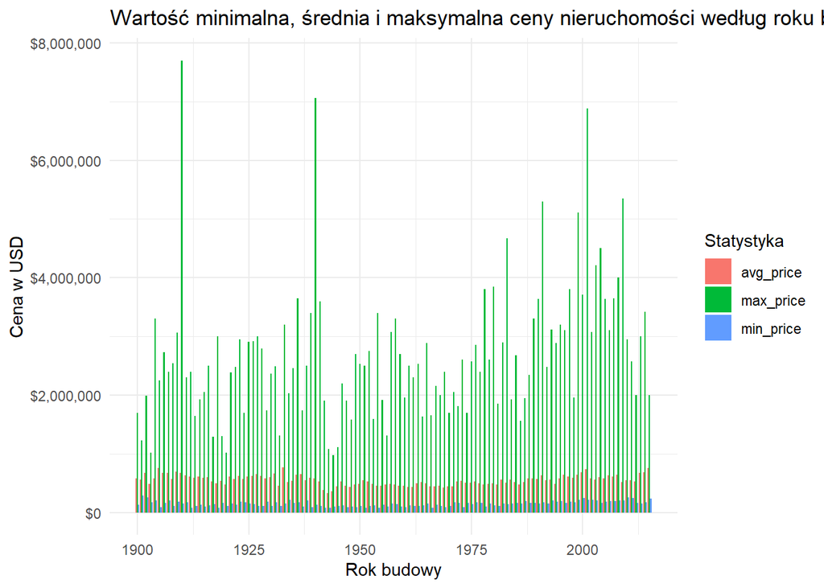

```r
df_6 <- price_summary <- house_data %>%
  group_by(yr_built) %>%
  summarise(
    min_price = min(price, na.rm = TRUE),
    avg_price = mean(price, na.rm = TRUE),
    max_price = max(price, na.rm = TRUE)
  ) %>%
  pivot_longer(cols = c(min_price, avg_price, max_price),
               names_to = "statistic", values_to = "price")
ggplot(df_6, aes(x = yr_built, y = price, fill = statistic)) +
  geom_bar(stat = "identity", position = "dodge") +
  labs(
    title = "Wartość minimalna, średnia i maksymalna ceny nieruchomości według roku budowy",
    x = "Rok budowy",
    y = "Cena w USD",
    fill = "Statystyka"
  ) +
  scale_y_continuous(labels = scales::dollar) +
  theme_minimal()
```

**Komentarz: Ciężko doszukać się zależności między upływem czasu a którąkolwiek ze statystyk. Średnia i minimum są mniej więcej stałe, natomiast są duże rozbieżności w cenie maksymalnej.**